# Latent variables

M. Rolland

03/12/2020

# Intro

Here I discuss the best way to combine the scores within a group. We want a method that we can do by hand to be able to perform a mixed model (and not a SEM) and also a method that provides a score in a unit that is convenient to interpret.

I use as an example the mean number of fixations at task 1 and task 2 for 24 month infants.

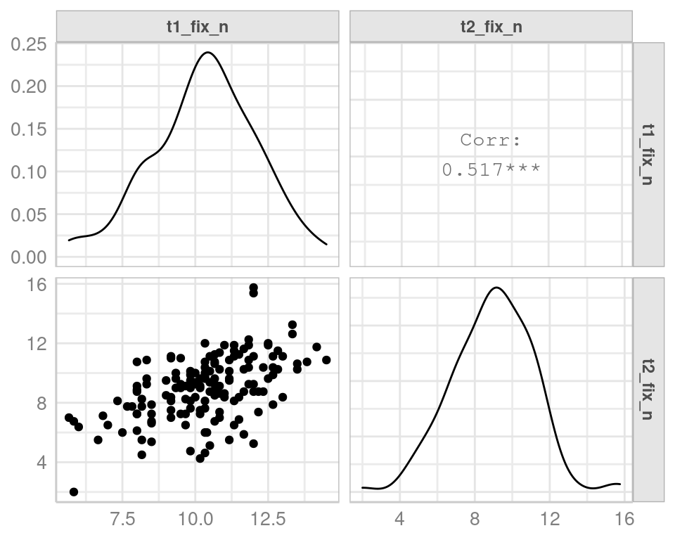

# Arthmetic and gemotric mean

Given the distributions arithmetic mean or geometric mean shouldn’t change much. Geometric mean is usually used to limit the effect of outliers.

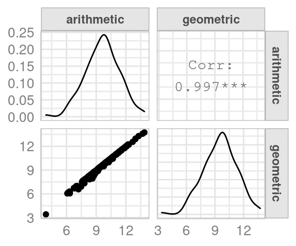

- Very correlated, would keep arithmetic as most “common” and understood and no problem with outliers

# Z-scores

Z-scores are better in case of different variance across groups, doesn’t seem to be the case here though.

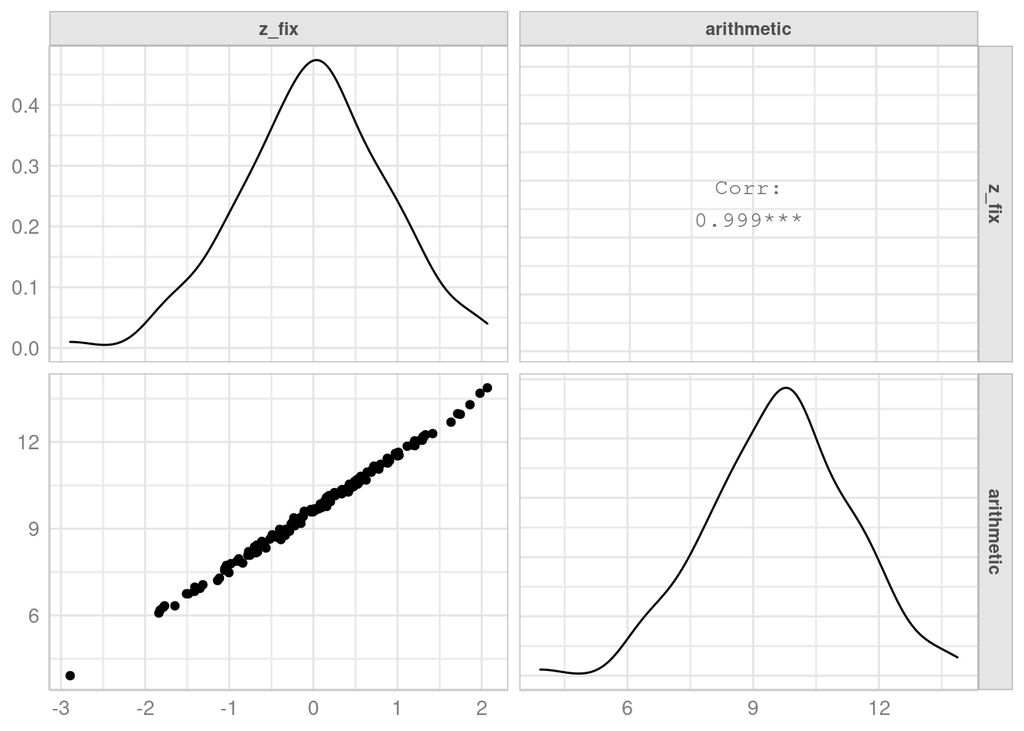

- colinear, no need to use z-scores

# Random intercept

Will be equal to the arithmetic mean in the case of a model without covariates.

Confirmation:

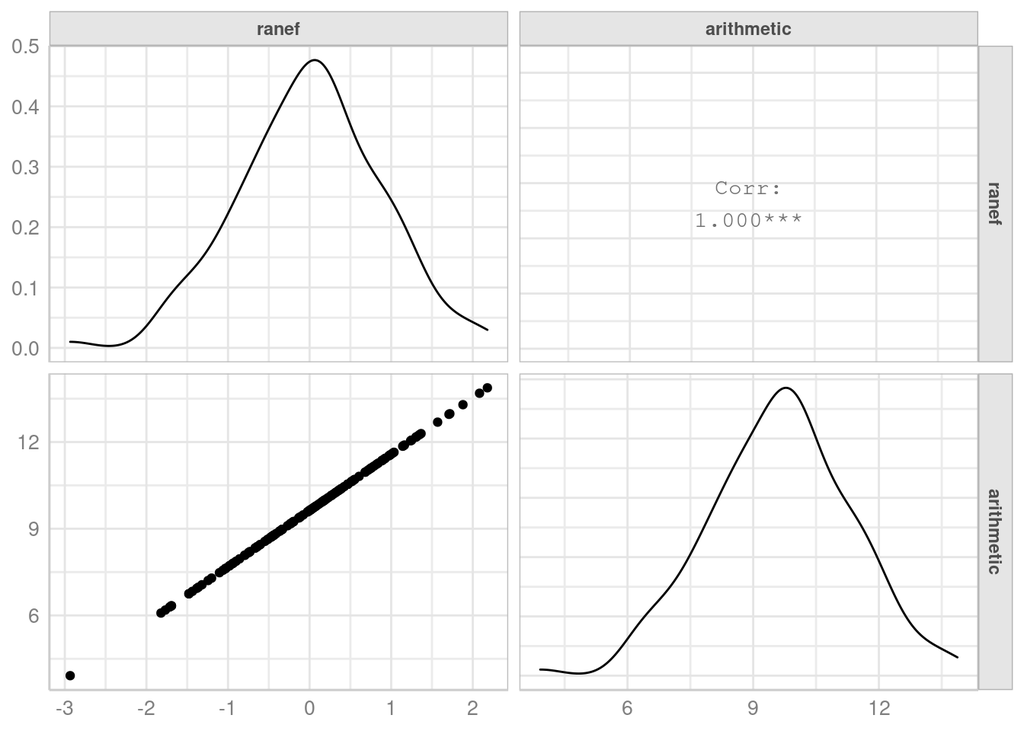

# Measurement error model

Could be interesting if variability seemed to differ from one measure to the other, which is not the case here.

# Conclusions

Given the fact we have normal distributions and no ooutliers, the mean seems to be OK.